# Code implementing the Statistical Analysis Plans: Identifying biomarkers for cancer prognosis

- Show All Code
- Hide All Code
- View Source

2026

statistical analysis plan

univariable selection

prediction

biomarker

case study

pre-defined model

Authors

Affiliations

Daniela Dunkler, Theresa Ullmann and Georg Heinze

Medical University of Vienna, Austria

Franziska Kappenberg

University of Bonn, Germany

Published

October 27, 2026

This document implements the two statistical analysis plans, on the same 248-patient dataset, comparing two contrasting analysis strategies for predicting disease-free survival in breast cancer patients from PMP22 gene expression and four established clinical factors (tumour size `pT`, nodal status `pN`, differentiation grade `G`, and estrogen receptor status `ER`).

# Content

Two contrasting analyses for the same prediction problem are presented.

- Section 1: Implementation of the pre-specified multivariable strategy consistent with current best-practice guidance (SAP A).
- Section 2: Implementation of the common but flawed workflow built on univariable variable selection (SAP B).
- Section 3: Comparison of both approaches.

Both parts use *identical* data. Any difference in conclusions is attributable to the **statistical strategy**, not to the data. The underlying study is Tong et al. (2010). We work with 248 of the 249 patients reported there (Heinze and Tong 2026).

# Data preparation (shared by both parts)

## Required packages

```r
library(survival)        # Cox regression, Surv objects
library(mice)            # multiple imputation by chained equations
library(rms)             # Harrell's regression modeling strategies toolkit
library(riskRegression)  # time-dependent AUC, Brier score, Index of Prediction Accuracy, bootstrap CV
library(MASS)            # stepAIC (used deliberately in the flawed Plan B)
library(car)             # generalized variance inflation factors
library(vcd)             # Cramer's V for the predictor-association heatmap (A.2)
library(DiagrammeR)      # patient flow chart (A.2)
library(ggplot2)
library(survminer)
library(knitr)

knitr::opts_chunk$set(fig.align = "center")
```

## Import and variable preparation

The data are loaded and prepared for analysis.

```r
df <- read.csv("data/data_pmp22.csv")
df$X <- NULL   # drop the row-index column

# PMP22, pN, ER are binary; pT and G are ordinal with 3 categories.
# We keep both a "raw" numeric/integer version (needed for linear/ordinal
# coding in Cox models) and labelled factor versions (needed for readable
# tables and plots).
df$PMP22_f <- factor(df$PMP22, levels = c(0, 1), labels = c("low", "high"))
df$pN_f    <- factor(df$pN,    levels = c(0, 1), labels = c("node-negative", "node-positive"))
df$ER_f    <- factor(df$ER,    levels = c(0, 1), labels = c("negative", "positive"))
df$pT_f    <- factor(df$pT,    levels = c(1, 2, 3), labels = c("pT1", "pT2", "pT3/pT4"), ordered = TRUE)
df$G_f     <- factor(df$G,     levels = c(1, 2, 3), labels = c("G1", "G2", "G3"), ordered = TRUE)

# str(df[, c("PMP22", "pT", "pN", "G", "ER", "days", "rezs")])

head(df)
```

```
  PMP22 pT pN  G ER days rezs PMP22_f          pN_f     ER_f pT_f  G_f
1     1  1 NA  2  0  271    1    high          <NA> negative  pT1   G2
2     0  2 NA  1  0  345    0     low          <NA> negative  pT2   G1
3     0  2  1  2  0  307    0     low node-positive negative  pT2   G2
4     0  2  1  3  0  376    1     low node-positive negative  pT2   G3
5     1  1  1 NA  0  143    1    high node-positive negative  pT1 <NA>
6     0  2  1  2  0  422    1     low node-positive negative  pT2   G2
```

# 1 SAP A: Pre-specified multivariable prediction model

## A.1 Objective

A multivariable Cox model with all five pre-specified predictors (`PMP22`, `pT`, `pN`, `G`, `ER`) entered simultaneously is estimated to quantify the adjusted prognostic contribution of PMP22 alongside the established clinical factors, and to report its prediction performance. No predictor is excluded based on its own (univariable) association with the outcome.

## A.2 Initial data analysis (IDA)

### Patient flow

Of the 249 patients reported in the original publication (Tong et al. 2010), 248 are available in the public dataset (Heinze and Tong 2026) and form the analysis population for both SAPs. Within these 248, 208 (83.9%) are complete on all five predictors and enter the complete-case analyses below. The remaining 40 (16.1%) have at least one missing predictor and are handled via multiple imputation (primary analysis) or excluded (complete-case sensitivity check).

```r
grViz('
digraph patient_flow {
  graph [layout = dot, rankdir = TB, nodesep = 0.4, ranksep = 0.45,
         fontsize = 11, fontname = Helvetica]
  node [shape = box, style = "rounded,filled", fillcolor = "#F2F2F2",
        color = "#4D4D4D", fontname = Helvetica, fontsize = 11,
        margin = "0.25,0.15"]
  edge [fontname = Helvetica, fontsize = 9, color = "#4D4D4D"]

  orig [label = "249 patients\\n(original publication)"]
  pub  [label = "248 patients\\n(public dataset;\\nanalysis population for both SAPs)"]
  cc   [label = "208 complete cases\\n(all 5 predictors observed)\\n=> complete-case analyses\\n(SAP B; SAP A sensitivity check)"]
  inc  [label = "40 patients with >=1\\nmissing predictor"]
  mi   [label = "All 248 patients,\\nmultiply imputed (m = 20)\\n=> SAP A primary analysis",
        fillcolor = "#E8F0FE"]

  orig -> pub [label = "1 patient not in\\npublic dataset"]
  pub  -> cc
  pub  -> inc
  pub  -> mi [style = dashed]
}
')
```

[interactive chart not shown]

Patient flow from the original publication to the analysis populations.

### Missingness

```r
miss_tab <- data.frame(
  variable = c("PMP22", "pT", "pN", "G", "ER"),
  n_missing = sapply(df[, c("PMP22", "pT", "pN", "G", "ER")], function(x) sum(is.na(x))),
  pct_missing = round(100 * sapply(df[, c("PMP22", "pT", "pN", "G", "ER")],
                                    function(x) mean(is.na(x))), 1)
)
kable(miss_tab, row.names = FALSE,
      caption = "Missing values per predictor (N = 248).")
```

Missing values per predictor (N = 248).

| variable | n_missing | pct_missing |
| --- | --- | --- |
| PMP22 | 1 | 0.4 |
| pT | 18 | 7.3 |
| pN | 29 | 11.7 |
| G | 21 | 8.5 |
| ER | 1 | 0.4 |

```r
n_complete <- sum(complete.cases(df[, c("PMP22", "pT", "pN", "G", "ER")]))
cat(sprintf("Complete cases on all 5 predictors: %d / %d (%.1f%%)\n",
            n_complete, nrow(df), 100 * n_complete / nrow(df)))
```

```
Complete cases on all 5 predictors: 208 / 248 (83.9%)
```

### Baseline characteristics

Descriptive distribution of the five predictors, complete cases only (n = 208). It is shown for plausibility-checking (A.2), not for variable selection. No predictor is included or excluded on the basis of these or any other univariate/outcome association (see A.6).

```r
cc0 <- df[complete.cases(df[, c("PMP22", "pT", "pN", "G", "ER")]), ]

baseline_row <- function(varname, label) {
  tab <- table(cc0[[varname]])
  data.frame(
    Variable = c(label, rep("", length(tab) - 1)),
    Category = names(tab),
    `N (%)`  = sprintf("%d (%.1f%%)", as.integer(tab), 100 * as.integer(tab) / sum(tab)),
    check.names = FALSE
  )
}

baseline_tab <- rbind(
  baseline_row("PMP22_f", "PMP22"),
  baseline_row("pN_f",    "Nodal status (pN)"),
  baseline_row("ER_f",    "Estrogen receptor (ER)"),
  baseline_row("pT_f",    "Tumour stage (pT)"),
  baseline_row("G_f",     "Grade (G)")
)
kable(baseline_tab, row.names = FALSE)
```

Baseline characteristics of the complete-case analysis set.

| Variable | Category | N (%) |
| --- | --- | --- |
| PMP22 | low | 102 (49.0%) |
|  | high | 106 (51.0%) |
| Nodal status (pN) | node-negative | 88 (42.3%) |
|  | node-positive | 120 (57.7%) |
| Estrogen receptor (ER) | negative | 95 (45.7%) |
|  | positive | 113 (54.3%) |
| Tumour stage (pT) | pT1 | 56 (26.9%) |
|  | pT2 | 116 (55.8%) |
|  | pT3/pT4 | 36 (17.3%) |
| Grade (G) | G1 | 29 (13.9%) |
|  | G2 | 113 (54.3%) |
|  | G3 | 66 (31.7%) |

PMP22 and ER are strongly positively associated (chi-squared test, p < 0.001), which is the correlation that masks PMP22’s adjusted effect in the univariable screen of SAP B (Section B.1):

```r
# helper: cross-tabulation with counts and row percentages, "n (row %)",
# plus a row total column; rows = x (percentages sum to 100% within each row)
xtab_rowpct <- function(x, y, xlab, ylab) {
  tab <- table(x, y)
  rs  <- rowSums(tab)
  out <- matrix(sprintf("%d (%.1f%%)", as.integer(tab), 100 * as.integer(tab) / rep(rs, ncol(tab))),
                nrow = nrow(tab), dimnames = list(NULL, colnames(tab)))
  out <- data.frame(rownames(tab), out, sprintf("%d (100%%)", as.integer(rs)),
                    check.names = FALSE)
  names(out) <- c(xlab, paste0(ylab, ": ", colnames(tab)), "Total")
  out
}

kable(xtab_rowpct(cc0$PMP22_f, cc0$ER_f, "PMP22", "ER"),
      row.names = FALSE,
      caption = "PMP22 by ER status, complete cases (n = 208); n (row %).")
```

PMP22 by ER status, complete cases (n = 208); n (row %).

| PMP22 | ER: negative | ER: positive | Total |
| --- | --- | --- | --- |
| low | 67 (65.7%) | 35 (34.3%) | 102 (100%) |
| high | 28 (26.4%) | 78 (73.6%) | 106 (100%) |

As planned (A.2), the remaining pairwise cross-tabulations among the five predictors are inspected as well, for plausibility only (not against the outcome, and not for variable selection):

**Pairwise cross-tabulations among the five predictors**

```r
pred_vars   <- c("PMP22_f", "pN_f", "ER_f", "pT_f", "G_f")
pred_labels <- c(PMP22_f = "PMP22", pN_f = "Nodal status (pN)",
                  ER_f = "Estrogen receptor (ER)", pT_f = "Tumour stage (pT)",
                  G_f = "Grade (G)")

pred_pairs <- combn(pred_vars, 2, simplify = FALSE)
# the PMP22 x ER pair is shown separately above; the remaining 9 pairs follow
pred_pairs <- pred_pairs[!sapply(pred_pairs, function(p) all(c("PMP22_f","ER_f") %in% p))]

for (p in pred_pairs) {
  tab <- xtab_rowpct(cc0[[p[1]]], cc0[[p[2]]], pred_labels[p[1]], pred_labels[p[2]])
  cat("\n\n", pred_labels[p[1]], "by", pred_labels[p[2]], "; n (row %)\n\n")
  print(kable(tab, row.names = FALSE))
}
```

PMP22 by Nodal status (pN) ; n (row %)

| PMP22 | Nodal status (pN): node-negative | Nodal status (pN): node-positive | Total |
| --- | --- | --- | --- |
| low | 41 (40.2%) | 61 (59.8%) | 102 (100%) |
| high | 47 (44.3%) | 59 (55.7%) | 106 (100%) |

PMP22 by Tumour stage (pT) ; n (row %)

| PMP22 | Tumour stage (pT): pT1 | Tumour stage (pT): pT2 | Tumour stage (pT): pT3/pT4 | Total |
| --- | --- | --- | --- | --- |
| low | 25 (24.5%) | 59 (57.8%) | 18 (17.6%) | 102 (100%) |
| high | 31 (29.2%) | 57 (53.8%) | 18 (17.0%) | 106 (100%) |

PMP22 by Grade (G) ; n (row %)

| PMP22 | Grade (G): G1 | Grade (G): G2 | Grade (G): G3 | Total |
| --- | --- | --- | --- | --- |
| low | 6 (5.9%) | 51 (50.0%) | 45 (44.1%) | 102 (100%) |
| high | 23 (21.7%) | 62 (58.5%) | 21 (19.8%) | 106 (100%) |

Nodal status (pN) by Estrogen receptor (ER) ; n (row %)

| Nodal status (pN) | Estrogen receptor (ER): negative | Estrogen receptor (ER): positive | Total |
| --- | --- | --- | --- |
| node-negative | 39 (44.3%) | 49 (55.7%) | 88 (100%) |
| node-positive | 56 (46.7%) | 64 (53.3%) | 120 (100%) |

Nodal status (pN) by Tumour stage (pT) ; n (row %)

| Nodal status (pN) | Tumour stage (pT): pT1 | Tumour stage (pT): pT2 | Tumour stage (pT): pT3/pT4 | Total |
| --- | --- | --- | --- | --- |
| node-negative | 36 (40.9%) | 47 (53.4%) | 5 (5.7%) | 88 (100%) |
| node-positive | 20 (16.7%) | 69 (57.5%) | 31 (25.8%) | 120 (100%) |

Nodal status (pN) by Grade (G) ; n (row %)

| Nodal status (pN) | Grade (G): G1 | Grade (G): G2 | Grade (G): G3 | Total |
| --- | --- | --- | --- | --- |
| node-negative | 13 (14.8%) | 51 (58.0%) | 24 (27.3%) | 88 (100%) |
| node-positive | 16 (13.3%) | 62 (51.7%) | 42 (35.0%) | 120 (100%) |

Estrogen receptor (ER) by Tumour stage (pT) ; n (row %)

| Estrogen receptor (ER) | Tumour stage (pT): pT1 | Tumour stage (pT): pT2 | Tumour stage (pT): pT3/pT4 | Total |
| --- | --- | --- | --- | --- |
| negative | 27 (28.4%) | 57 (60.0%) | 11 (11.6%) | 95 (100%) |
| positive | 29 (25.7%) | 59 (52.2%) | 25 (22.1%) | 113 (100%) |

Estrogen receptor (ER) by Grade (G) ; n (row %)

| Estrogen receptor (ER) | Grade (G): G1 | Grade (G): G2 | Grade (G): G3 | Total |
| --- | --- | --- | --- | --- |
| negative | 6 (6.3%) | 50 (52.6%) | 39 (41.1%) | 95 (100%) |
| positive | 23 (20.4%) | 63 (55.8%) | 27 (23.9%) | 113 (100%) |

Tumour stage (pT) by Grade (G) ; n (row %)

| Tumour stage (pT) | Grade (G): G1 | Grade (G): G2 | Grade (G): G3 | Total |
| --- | --- | --- | --- | --- |
| pT1 | 12 (21.4%) | 31 (55.4%) | 13 (23.2%) | 56 (100%) |
| pT2 | 11 (9.5%) | 61 (52.6%) | 44 (37.9%) | 116 (100%) |
| pT3/pT4 | 6 (16.7%) | 21 (58.3%) | 9 (25.0%) | 36 (100%) |

As a compact complement to the 10 individual cross-tabulations, pairwise association strength is also summarised visually using Cramer’s V, which ranges from 0 (no association) to 1 (perfect association) and is a single-number summary for cross-tabulations of categorical variables :

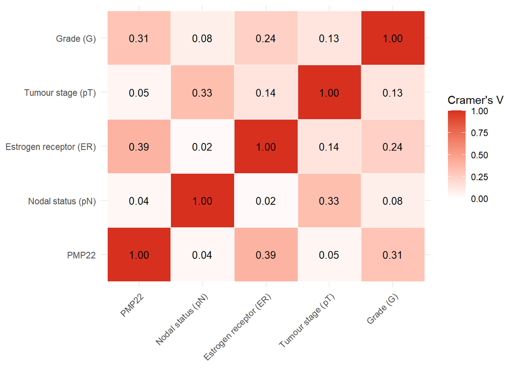

Pairwise association strength (Cramer’s V) among the five predictors, complete cases (n = 208). The diagonal is fixed at 1 by definition.

```r
assoc_mat <- matrix(1, nrow = length(pred_vars), ncol = length(pred_vars),
                     dimnames = list(pred_labels[pred_vars], pred_labels[pred_vars]))
for (p in combn(pred_vars, 2, simplify = FALSE)) {
  v <- suppressWarnings(assocstats(table(cc0[[p[1]]], cc0[[p[2]]]))$cramer)
  assoc_mat[pred_labels[p[1]], pred_labels[p[2]]] <- v
  assoc_mat[pred_labels[p[2]], pred_labels[p[1]]] <- v
}

assoc_df <- as.data.frame(as.table(assoc_mat))
names(assoc_df) <- c("Var1", "Var2", "CramersV")

ggplot(assoc_df, aes(Var1, Var2, fill = CramersV)) +
  geom_tile(color = "white") +
  geom_text(aes(label = sprintf("%.2f", CramersV)), size = 3.5) +
  scale_fill_gradient(low = "white", high = "#D7301F", limits = c(0, 1),
                       name = "Cramer's V") +
  labs(x = NULL, y = NULL) +
  theme_minimal(base_size = 11) +
  theme(axis.text.x = element_text(angle = 45, hjust = 1))
```

The heatmap confirms the PMP22-ER association noted above (Cramer’s V = 0.39) and shows no other pairwise association among the five predictors strong enough to raise plausibility concerns. As with the individual cross-tabulations, this is a descriptive plausibility check (A.2).

### Plausibility of missing-at-random

208 of 248 patients (83.9%) are complete on all five predictors. This moderate degree of missingness (up to ~12% for nodal status) motivates using multiple imputation as the primary analysis (Section A.5) rather than discarding ~16% of patients via complete-case analysis.

As an exploratory check, we regress the missingness indicator of each of variable on the remaining predictors and the outcome (event indicator, log follow-up time) using logistic regression. Such a check can only reveal dependence of missingness on observed data (i.e., evidence against missing-completely-at-random MCAR). It cannot verify missing-at-random MAR, which concerns the unobserved values and is untestable. Conversely, non-significant results are not proof of MCAR, as power is limited by the small number of missing values.

**Plausibility of missing-at-random**

```r
cat("\nNumber of missing observations for each variable\n")
```

```
Number of missing observations for each variable
```

```r
apply(is.na(df[,1:7]),2,sum)
```

```
PMP22    pT    pN     G    ER  days  rezs
    1    18    29    21     1     0     0
```

```r
check_missing_assoc <- function(varname) {
  d <- df
  d$miss_ind <- as.integer(is.na(d[[varname]]))
  predictors <- setdiff(c("PMP22", "pT", "pN", "G", "ER"), varname)
  form <- as.formula(paste("miss_ind ~", paste(predictors, collapse = " + "),
                           "+ rezs + log(days)"))
  fit <- glm(form, data = d, family = binomial)
  s <- summary(fit)$coefficients[-1, , drop = FALSE]
  data.frame(OR = exp(s[, "Estimate"]), p = s[, "Pr(>|z|)"]) |> round(3)
}

for (v in c("PMP22", "pT", "pN", "G", "ER")) {
  cat("\nMissingness of", v, "regressed on remaining variables + outcome:\n")
  print(check_missing_assoc(v))
}
```

```
Missingness of PMP22 regressed on remaining variables + outcome:
```

```
          OR p
pT         1 1
pN         1 1
G          1 1
ER         1 1
rezs       1 1
log(days)  1 1

Missingness of pT regressed on remaining variables + outcome:
```

```
                    OR     p
PMP22     1.997000e+00 0.643
pN        4.610000e-01 0.606
G         1.748000e+00 0.689
ER        0.000000e+00 0.998
rezs      4.502397e+08 0.997
log(days) 1.895000e+00 0.524

Missingness of pN regressed on remaining variables + outcome:
             OR     p
PMP22     0.326 0.103
pT        0.733 0.498
G         0.459 0.091
ER        0.985 0.981
rezs      1.125 0.845
log(days) 0.873 0.468

Missingness of G regressed on remaining variables + outcome:
             OR     p
PMP22     1.778 0.477
pT        0.307 0.101
pN        0.544 0.493
ER        0.197 0.073
rezs      0.162 0.117
log(days) 0.889 0.669

Missingness of ER regressed on remaining variables + outcome:
```

```
          OR p
PMP22      1 1
pT         1 1
pN         1 1
G          1 1
rezs       1 1
log(days)  1 1
```

No association of missingness with the observed variables was statistically significant (all p > 0.05). So there is no evidence against MCAR. However, this does not establish it. Hence, we do not base the choice of method on this check. Because MAR is a more plausible assumption than MCAR and multiple imputation uses all 248 patients, multiple imputation (including the outcome in the imputation model) is the primary approach. The complete-case analysis is reported as a sensitivity analysis.

*Note on ER completeness*: the original publication reports ER missing in 22.5% of cases at the immunohistochemistry stage but re-classified nearly all patients using an mRNA-expression-based surrogate. This explains why ER is almost fully observed here (1 missing) despite the more substantial original missingness. This is a data-provenance detail worth documenting, not a statistical result.

## A.3 Outcome description

```r
cat("Number of events (recurrence):", sum(df$rezs), "/", nrow(df),
    sprintf("(%.1f%%)\n", 100*mean(df$rezs)))
```

```
Number of events (recurrence): 109 / 248 (44.0%)
```

```r
# Median potential follow-up via the reverse Kaplan-Meier method
# (Schemper & Smith, 1996) -- the appropriate way to summarise follow-up
# duration in survival studies, rather than simply the median observed time.
revkm <- survfit(Surv(days, 1 - rezs) ~ 1, data = df)
cat("Median potential follow-up (reverse KM):", summary(revkm)$table["median"],
    "days (~", round(summary(revkm)$table["median"] / 365.25, 1), "years)\n")
```

```
Median potential follow-up (reverse KM): 3246 days (~ 8.9 years)
```

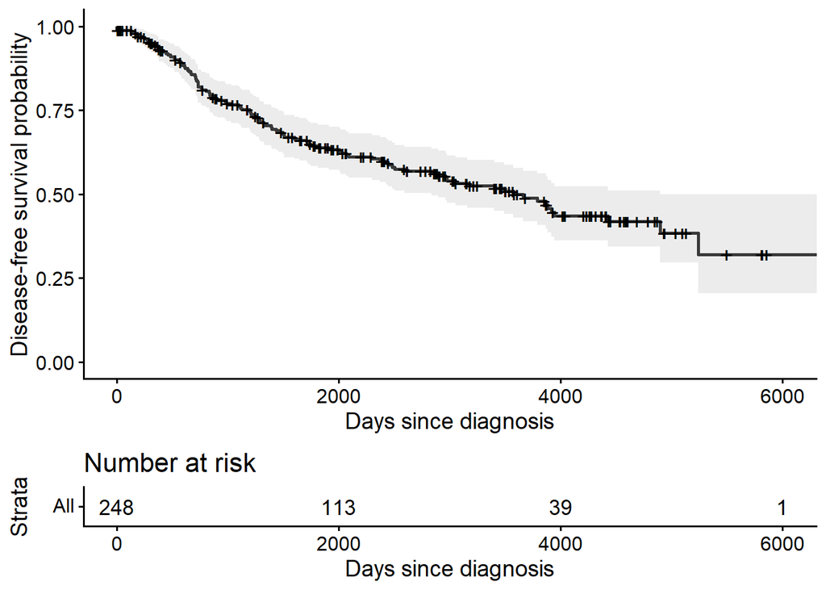

Kaplan-Meier estimate of disease-free survival, all 248 patients.

```r
fit_km <- survfit(Surv(days, rezs) ~ 1, data = df)
ggsurvplot(fit_km, data = df, risk.table = TRUE, conf.int = TRUE,
           xlab = "Days since diagnosis", ylab = "Disease-free survival probability",
           legend = "none", palette = "black")
```

With 109 events among 248 patients (44.0%), and 5 predictors entered as main effects (see A.4 below for their coding), events per parameter is (21.8 using linear/ordinal coding for `pT`/`G`, 15.6 if coded as free 3-level factors instead).

## A.4 Functional form of ordinal predictors

`pT` and `G` are ordinal with 3 levels. We compare a parsimonious linear (ordinal-score) coding against a free 3-level categorical coding via a likelihood-ratio test, on the complete-case subset. (This functional-form check is separate from, and does not constitute, variable *selection*, as all five predictors remain in the model regardless of the outcome.)

```r
cc <- df[complete.cases(df[, c("PMP22", "pT", "pN", "G", "ER")]), ]
cat("Complete-case analysis set: n =", nrow(cc), "\n")
```

```
Complete-case analysis set: n = 208
```

```r
m_pT_lin <- coxph(Surv(days, rezs) ~ pT, data = cc)
m_pT_cat <- coxph(Surv(days, rezs) ~ factor(pT), data = cc)
cat("pT: linear vs. categorical coding, likelihood-ratio test p =",
    round(anova(m_pT_lin, m_pT_cat)$`Pr(>|Chi|)`[2], 3), "\n")
```

```
pT: linear vs. categorical coding, likelihood-ratio test p = 0.612
```

```r
m_G_lin <- coxph(Surv(days, rezs) ~ G, data = cc)
m_G_cat <- coxph(Surv(days, rezs) ~ factor(G), data = cc)
cat("G:  linear vs. categorical coding, likelihood-ratio test p =",
    round(anova(m_G_lin, m_G_cat)$`Pr(>|Chi|)`[2], 3), "\n")
```

```
G:  linear vs. categorical coding, likelihood-ratio test p = 0.099
```

Neither test supports departure from linearity: both likelihood-ratio test p-values are above the pre-specified $\alpha = 0.05$ threshold (A.4). Hence, we retain the more parsimonious linear (ordinal-score) coding for `pT` and `G`, improving events-per-parameter without discarding information on their ordering.

## A.6-A.8: Full model, assumption checks and interactions (complete-case)

Following the pre-specified analysis sequence (A.6): we first fit the full main-effects model on complete cases and check multicollinearity and proportional hazards (A.8) on it. Only then do we test the pre-specified interactions (A.7), against the resulting (possibly amended) model. This complete-case model is a diagnostic staging step. The final estimates come from the multiple-imputation model in Section A.5 below.

```r
fit_main <- coxph(Surv(days, rezs) ~ PMP22_f + pT + pN_f + G + ER_f,
                   data = cc, x = TRUE)
summary(fit_main)
```

```
Call:
coxph(formula = Surv(days, rezs) ~ PMP22_f + pT + pN_f + G +
    ER_f, data = cc, x = TRUE)

  n= 208, number of events= 93

                      coef exp(coef) se(coef)      z Pr(>|z|)
PMP22_fhigh        0.57211   1.77200  0.24586  2.327  0.01997 *
pT                 0.23985   1.27106  0.16093  1.490  0.13612
pN_fnode-positive  1.00127   2.72175  0.24339  4.114 3.89e-05 ***
G                 -0.01906   0.98112  0.17368 -0.110  0.91263
ER_fpositive      -0.72083   0.48635  0.23800 -3.029  0.00246 **
---
Signif. codes:  0 '***' 0.001 '**' 0.01 '*' 0.05 '.' 0.1 ' ' 1

                  exp(coef) exp(-coef) lower .95 upper .95
PMP22_fhigh          1.7720     0.5643    1.0944    2.8691
pT                   1.2711     0.7867    0.9272    1.7424
pN_fnode-positive    2.7217     0.3674    1.6892    4.3855
G                    0.9811     1.0192    0.6981    1.3790
ER_fpositive         0.4863     2.0561    0.3050    0.7754

Concordance= 0.683  (se = 0.027 )
Likelihood ratio test= 30.66  on 5 df,   p=1e-05
Wald test            = 27.08  on 5 df,   p=6e-05
Score (logrank) test = 28.6  on 5 df,   p=3e-05
```

### Multicollinearity (A.6/A.8)

```r
vif(fit_main)
```

```
 PMP22_f       pT     pN_f        G     ER_f
1.379962 1.092797 1.072611 1.167420 1.300273
```

All generalized VIFs are close to 1. They are well below common concern thresholds of 5 to 10. There is no problematic collinearity among the five predictors.

### Proportional hazards assumption (A.8)

```
          chisq df       p
PMP22_f  4.9350  1 0.02632
pT       0.0754  1 0.78365
pN_f     3.3913  1 0.06554
G        1.0453  1 0.30659
ER_f    14.9838  1 0.00011
GLOBAL  19.3868  5 0.00163
```

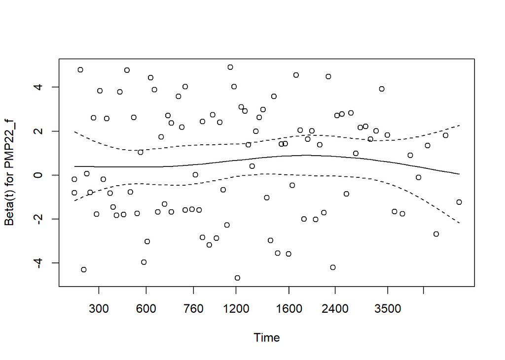

Scaled Schoenfeld residuals vs. time for each covariate.

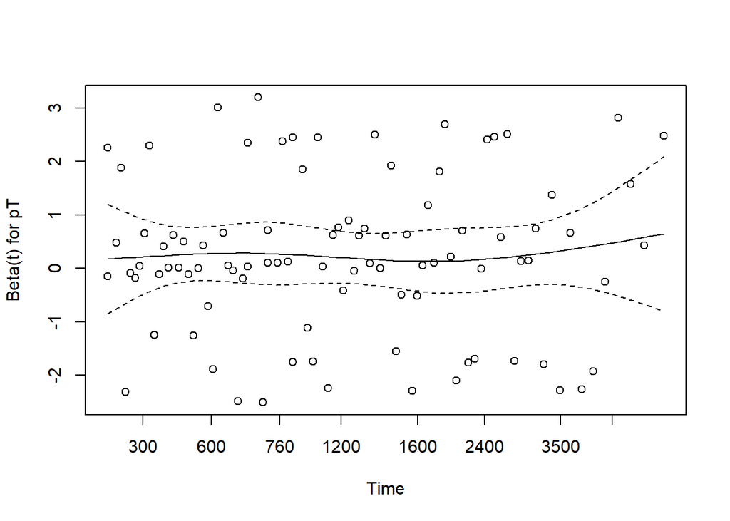

Scaled Schoenfeld residuals vs. time for each covariate.

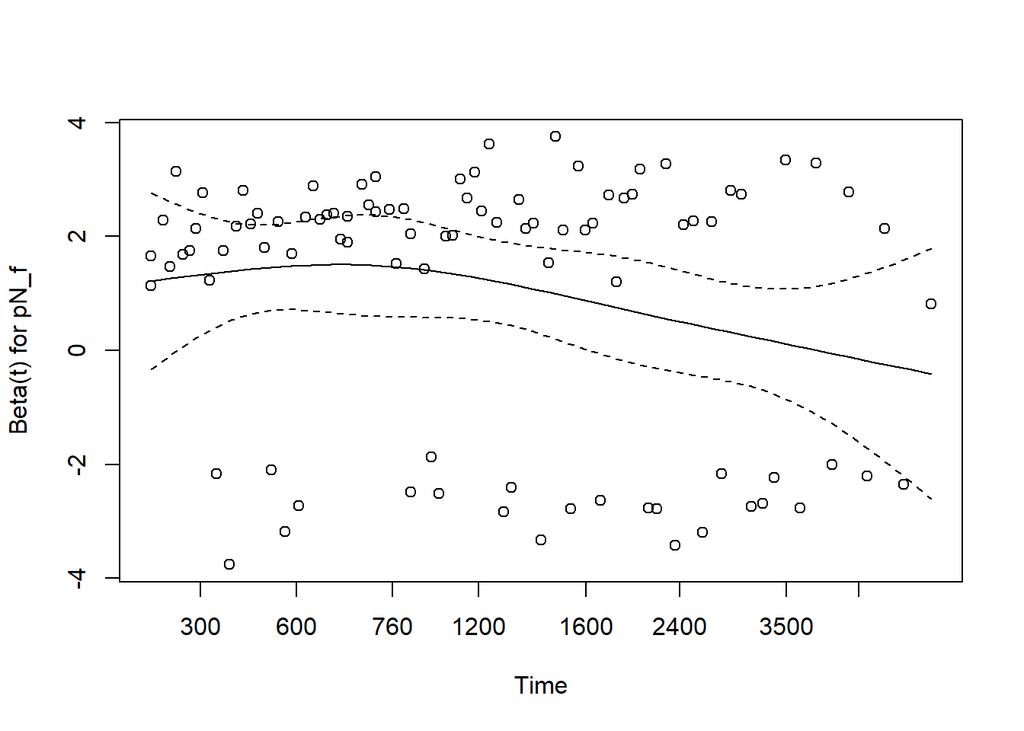

Scaled Schoenfeld residuals vs. time for each covariate.

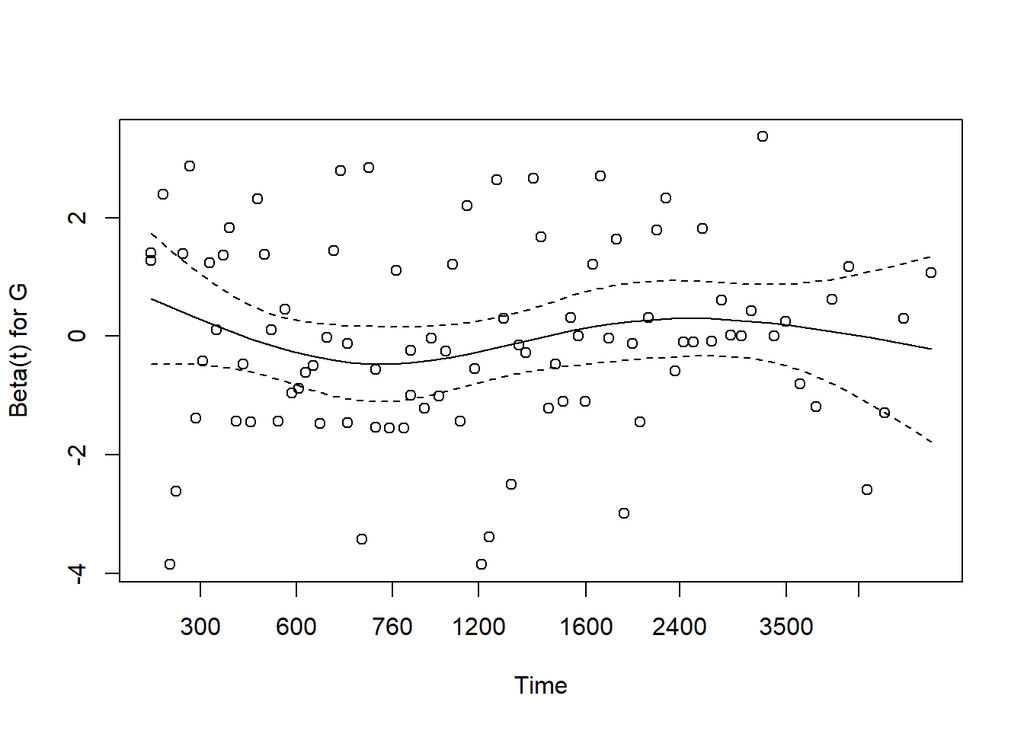

Scaled Schoenfeld residuals vs. time for each covariate.

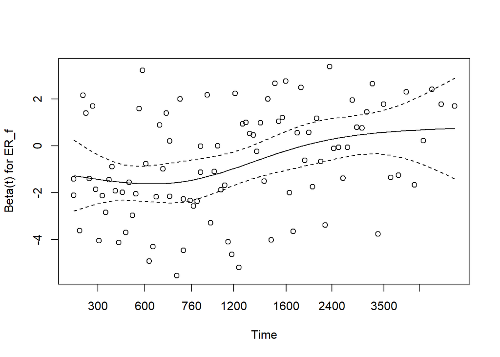

Scaled Schoenfeld residuals vs. time for each covariate.

```r
zph <- cox.zph(fit_main)
zph
plot(zph)
```

The proportional hazards assumption is clearly violated for `ER_f` (p < 0.001), with the global test also significant. This mirrors what Tong et al. (2010) themselves report and address in the source publication. We adopt the same remedy: a time-varying effect of ER, modelled as an interaction between ER and the logarithm of survival time. In code this is written as `ER_f x log(time)`. We refit the model with a time-varying effect of ER.

```r
fit_main_tv <- coxph(
  Surv(days, rezs) ~ PMP22_f + pT + pN_f + G + ER_f + tt(ER_f),
  data = cc,
  tt = function(x, t, ...) (as.numeric(x) - 1) * log(t)
)
summary(fit_main_tv)
```

```
Call:
coxph(formula = Surv(days, rezs) ~ PMP22_f + pT + pN_f + G +
    ER_f + tt(ER_f), data = cc, tt = function(x, t, ...) (as.numeric(x) -
    1) * log(t))

  n= 208, number of events= 93

                        coef  exp(coef)   se(coef)      z Pr(>|z|)
PMP22_fhigh        0.5436707  1.7223175  0.2420799  2.246  0.02471 *
pT                 0.2716359  1.3121092  0.1615257  1.682  0.09263 .
pN_fnode-positive  0.9598269  2.6112444  0.2431547  3.947  7.9e-05 ***
G                  0.0043493  1.0043588  0.1740147  0.025  0.98006
ER_fpositive      -7.0372595  0.0008785  2.1452435 -3.280  0.00104 **
tt(ER_f)           0.9084145  2.4803867  0.3022223  3.006  0.00265 **
---
Signif. codes:  0 '***' 0.001 '**' 0.01 '*' 0.05 '.' 0.1 ' ' 1

                  exp(coef) exp(-coef) lower .95 upper .95
PMP22_fhigh       1.7223175     0.5806 1.072e+00   2.76804
pT                1.3121092     0.7621 9.560e-01   1.80078
pN_fnode-positive 2.6112444     0.3830 1.621e+00   4.20553
G                 1.0043588     0.9957 7.141e-01   1.41257
ER_fpositive      0.0008785  1138.2639 1.311e-05   0.05886
tt(ER_f)          2.4803867     0.4032 1.372e+00   4.48509

Concordance= 0.704  (se = 0.029 )
Likelihood ratio test= 43.99  on 6 df,   p=7e-08
Wald test            = 34.68  on 6 df,   p=5e-06
Score (logrank) test = 37.72  on 6 df,   p=1e-06
```

**Interpreting the time-varying effect of ER:** in the model above the time-varying effect of ER is represented with `tt(ER_f)`. With this coding, the model estimates the ER-positive-vs-negative log hazard ratio at follow-up time $t$ (days) as $\beta_{ER} + \beta_{ER\times\log(t)} \times \log(t)$. The coefficient printed for `ER_f` is the log hazard ratio at $t = 1$ day (where $\log(t) = 0$), not an average, time-constant effect.

The coefficient printed for `tt(ER_f)` is the change in that log hazard ratio per unit increase in $\log(t)$, i.e., it quantifies *how* the ER effect evolves over follow-up rather than a hazard ratio in its own right. So it should not itself be exponentiated and reported as a hazard ratio. Here the estimated `tt(ER_f)` coefficient is 0.908. A positive coefficient means the ER effect shifts towards higher hazard (i.e., the protective effect of ER-positivity weakens) with longer follow-up, while a negative coefficient would mean the opposite.

The ER hazard ratio at any specific follow-up time can be obtained by evaluating $\exp(\beta_{ER} + \beta_{ER\times\log(t)}\times\log(t))$ at that value of $t$.

### Interactions (A.7), tested against the assumption-corrected model

The plan’s pre-specified analysis sequence (A.6) requires that interactions be tested only *after* proportional-hazards/functional-form assumptions have been checked, and against the resulting (possibly amended) main-effects model (i.e., the model with the `ER` time-varying term) rather than against the original, proportional hazards-violating specification. A small, pre-specified set of clinically motivated interactions (`PMP22 x ER`, `PMP22 x pN`, `PMP22 x pT`) is tested jointly with a single likelihood-ratio test, to avoid inflating the false-positive rate that would result from testing every pairwise combination individually.

```r
fit_int_tv <- coxph(
  Surv(days, rezs) ~ PMP22_f * ER_f + PMP22_f * pN_f + PMP22_f * pT + G + tt(ER_f),
  data = cc,
  tt = function(x, t, ...) (as.numeric(x) - 1) * log(t)
)
int_test  <- anova(fit_main_tv, fit_int_tv)
p_int_cc  <- int_test[["Pr(>|Chi|)"]][2]
int_test
```

```
Analysis of Deviance Table
 Cox model: response is  Surv(days, rezs)
 Model 1: ~ PMP22_f + pT + pN_f + G + ER_f + tt(ER_f)
 Model 2: ~ PMP22_f * ER_f + PMP22_f * pN_f + PMP22_f * pT + G + tt(ER_f)
   loglik  Chisq Df Pr(>|Chi|)
1 -419.18
2 -418.47 1.4011  3     0.7053
```

At the pre-specified $\alpha = 0.05$ (A.7), the joint test is not significant (p = 0.705). Per A.7, unless an interaction is both statistically compelling and clinically sensible, the primary reported prediction model retains only main effects (plus the `ER` time-varying term). Any retained interaction would in any case be treated as exploratory/hypothesis-generating given the limited events-per-parameter.

## A.5 Multiple imputation and pooled final model

We now impute the (moderate) missingness in the five predictors using multiple imputation by chained equations, and fit the model settled on above (linear `pT`/`G`, time-varying `ER`, no interactions) on each imputed dataset, pooling with Rubin’s rules.

Following White and Royston (2009), the imputation model for the predictors includes the **Nelson–Aalen estimator of the cumulative hazard** and the **event indicator**, rather than raw survival time, to preserve the covariate–outcome associations correctly.

```r
set.seed(852945)

df_mi <- df[, c("PMP22", "pT", "pN", "G", "ER", "days", "rezs")]
df_mi$nelsonH <- nelsonaalen(df_mi, days, rezs)
df_mi$PMP22 <- factor(df_mi$PMP22)
df_mi$pN    <- factor(df_mi$pN)
df_mi$ER    <- factor(df_mi$ER)
df_mi$pT    <- factor(df_mi$pT, ordered = TRUE)
df_mi$G     <- factor(df_mi$G,  ordered = TRUE)

imp0 <- mice(df_mi, maxit = 0)
meth <- imp0$method
meth["PMP22"] <- "logreg"; meth["pN"] <- "logreg"; meth["ER"] <- "logreg"
meth["pT"] <- "polr";      meth["G"]  <- "polr"
meth["days"] <- ""; meth["rezs"] <- ""; meth["nelsonH"] <- ""

pred <- imp0$predictorMatrix
pred[, "days"] <- 0   # use nelsonH + rezs instead of raw survival time
pred["days", ] <- 0
diag(pred) <- 0

# m chosen following White, Royston & Wood's rule of thumb:
# m >= 100 * fraction of incomplete cases (~16% here -> m >= 16); we use 20.
imp <- mice(df_mi, method = meth, predictorMatrix = pred, m = 20, maxit = 20,
            printFlag = FALSE, seed = 2026)

fit_imp <- with(imp, coxph(
  Surv(days, rezs) ~ PMP22 + as.numeric(pT) + pN + as.numeric(G) + ER + tt(ER),
  tt = function(x, t, ...) (as.numeric(x) - 1) * log(t)
))
pooled <- pool(fit_imp)
s <- summary(pooled, conf.int = TRUE)

hr_terms <- c("PMP22 (high vs. low)", "pT (per category)", "pN (positive vs. negative)",
              "G (per grade)", "ER (positive vs. negative, at t=1 day)", "ER x log(time)")

# 2 decimals throughout, except the ER HR at t = 1 day: it is close to 0 and
# would be reported as 0.00 with 2 decimals, so it is given to 4 decimals.
hr_digits <- ifelse(hr_terms == "ER (positive vs. negative, at t=1 day)", 4, 2)
fmt_hr <- function(x, d) unname(mapply(function(xx, dd) formatC(xx, format = "f", digits = dd),
                                       x, d))

hr_raw <- exp(s$estimate)   # unrounded HRs, used for derived quantities below

hr_table <- data.frame(
  term    = hr_terms,
  HR      = round(hr_raw, hr_digits),
  CI_low  = round(exp(s$`2.5 %`), hr_digits),
  CI_high = round(exp(s$`97.5 %`), hr_digits),
  p_value = s$p.value   # kept at full precision for re-use in the text below
)

hr_display <- hr_table
hr_display$HR      <- fmt_hr(hr_table$HR,      hr_digits)
hr_display$CI_low  <- fmt_hr(hr_table$CI_low,  hr_digits)
hr_display$CI_high <- fmt_hr(hr_table$CI_high, hr_digits)
hr_display$p_value <- format.pval(hr_display$p_value, digits = 3, eps = 0.001)

# the ER x log(time) term is not a hazard ratio: show only its p-value
# (HR and CI blank); the coefficient is given in the footnote below
i_tt <- hr_display$term == "ER x log(time)"
hr_display$HR[i_tt] <- ""; hr_display$CI_low[i_tt] <- ""; hr_display$CI_high[i_tt] <- ""
hr_display$term[i_tt] <- "ER x log(time)^a^"

# pooled coefficient (log scale) and SE of the time-varying ER term, for the footnote
b_tt  <- s$estimate[hr_terms == "ER x log(time)"]
se_tt <- s$std.error[hr_terms == "ER x log(time)"]

kable(hr_display, row.names = FALSE,
      caption = "Final pooled multivariable Cox model (m = 20 imputations, Rubin's rules).")
```

Final pooled multivariable Cox model (m = 20 imputations, Rubin’s rules).

| term | HR | CI_low | CI_high | p_value |
| --- | --- | --- | --- | --- |
| PMP22 (high vs. low) | 1.47 | 0.94 | 2.29 | 0.090 |
| pT (per category) | 1.24 | 0.90 | 1.70 | 0.181 |
| pN (positive vs. negative) | 2.68 | 1.64 | 4.36 | <0.001 |
| G (per grade) | 0.93 | 0.67 | 1.28 | 0.643 |
| ER (positive vs. negative, at t=1 day) | 0.0041 | 0.0001 | 0.1399 | 0.003 |
| ER x log(time)<sup>a</sup> |  |  |  | 0.007 |

<sup>a</sup> Time-varying effect of ER, modelled as ER x log(time): the pooled coefficient is $\hat\beta_{ER \times \log(t)}$ = 0.690 (SE 0.251) on the log-hazard scale. It is the change in the ER log hazard ratio per one-unit increase in log(days)

### Congenial interaction test under multiple imputation

As noted in the plan (A.5), testing the pre-specified interactions only on complete cases (as done above, in A.6/A.7) is not congenial with an imputation model that itself excludes those interaction terms. Because `PMP22`, `ER`, `pN`, and `pT` are imputed directly, the interaction products can be formed on the fly, within `with()`, from the already-imputed variables in each of the 20 completed datasets. This needs no separate passive-imputation step. We fit an interaction-augmented version of the pooled model and compare it to `fit_imp` with a multivariate Wald test (`mice::D1()`), the standard multiple-imputation analogue of a joint likelihood-ratio test.

```r
fit_imp_int <- with(imp, coxph(
  Surv(days, rezs) ~ PMP22 * ER + PMP22 * pN + PMP22 * as.numeric(pT) +
    as.numeric(pT) + as.numeric(G) + tt(ER),
  tt = function(x, t, ...) (as.numeric(x) - 1) * log(t)
))
D1(fit_imp_int, fit_imp)
```

```
   test statistic df1      df2 dfcom   p.value        riv
 1 ~~ 2 0.6204028   3 96.97608   100 0.6034651 0.06685693
```

This multiple imputation-based joint test is the primary check for the interaction terms. The complete-case version above (A.6/A.7) is retained as a consistency check. If both agree that the interactions are not significant at the pre-specified $\alpha = 0.05$, the main-effects-only (plus `ER` time-varying) model above remains the primary reported result. If they disagree, this would need to be reconciled before finalizing the model.

**Primary result:** *after multiple imputation and adjustment for the four established clinical factors, patients with high PMP22 expression have a 1.47-fold (95% CI 0.94 - 2.29) higher hazard of recurrence than patients with low PMP22 expression (p = 0.09).* The point estimate is directionally consistent with, but numerically somewhat lower than, the published estimate (HR 1.77, p = 0.02) and than the complete-case estimate with the same time-varying-ER specification (HR 1.72, p = 0.025, Section A.6-A.8 above). The wider confidence interval and the p-value no longer crossing the conventional 0.05 threshold reflect that multiple imputation propagates the extra uncertainty from the 16.1% of cases with missing predictors, which the complete-case analysis cannot. The lower point estimate may reflect the imputation itself (cases with missing predictors contribute information that the complete-case analysis discards) and the slightly different sample (248 vs. 249 patients). The data alone cannot tell these apart. Taken together, both analyses agree on the qualitative, substantive conclusion motivating this case study: **PMP22’s adjusted association with recurrence is materially stronger than its univariable association** (HR 1.01, p = 0.98, Section B.1). This is the opposite of what a univariable screen would suggest (see SAP B), even though, after propagating imputation uncertainty, the adjusted estimate itself is no longer significant at the conventional 5% level.

## A.9 Prediction performance and internal validation

### Multiple imputation-pooled bootstrap optimism-correction (primary analysis)

Per the plan (A.9), the bootstrap optimism-correction is combined with multiple imputation by repeating the full bootstrap procedure *within* each of the 20 imputed datasets separately. The resulting optimism-corrected estimates from each imputed dataset are then pooled across imputations using Rubin’s rules, so that imputation uncertainty is reflected in the reported standard error.

We illustrate this for Harrell’s C-index, the calibration slope, the explained-variation measure (Nagelkerke’s pseudo-R^2 for Cox models), the time-dependent AUC, Brier score and Index of Prediction Accuracy summary, all using the *non-time-varying* model specification. Pooling proceeds the same way throughout: the full bootstrap (or bootstrap-cross-validation) procedure is repeated within each of the 20 imputed datasets, and the resulting estimates are combined across imputations using Rubin’s rules.

*Why the non-time-varying model is used for all performance measures.* The C-index, the calibration slope and the explained-variation measure summarise how well a single risk score per patient (the linear predictor) ranks and calibrates patients. With a time-varying effect of `ER`, the patients’ ranking changes over follow-up, so no single risk score exists. For the time-dependent AUC, Brier score and Index of Prediction Accuracy we use the same model, so that all performance measures describe the same model.

*Likely consequences.* The constant `ER` effect is an average over follow-up, and the proportional hazards assumption is violated for `ER` (A.8). Therefore, the model whose performance is reported here differs from the final model in A.5 (Table 2) including the time-varying `ER` term and is probably somewhat less accurate. Discrimination and calibration may thus be slightly mis-estimated, in particular for predictions early or late in follow-up. Because only one of the five predictors is affected, we would expect the differences to be small. The results should be read as approximate.

```r
# Bootstrap optimism-correction for Harrell's C-index, the calibration
# slope, and the explained-variation measure (Nagelkerke's pseudo-R^2 for
# Cox models), repeated within each imputed dataset and pooled across
# imputations with Rubin's rules. The calibration-slope and R^2
# replicates reuse the same bootstrap-fitted model as the C-index
# replicate (fit_b):
# - slope_test is the coefficient obtained from refitting Surv ~ lp on
#   the original data using fit_b's linear predictor (Steyerberg-style
#   calibration slope); a value < 1 indicates overfitting.
# - r2_test is Nagelkerke's R^2 (Nagelkerke, 1991), computed from the
#   partial log-likelihood of fit_b's linear predictor evaluated on the
#   original data (via a zero-free-parameter, offset-only Cox model),
#   relative to the null-model log-likelihood on the original data. This
#   is the same explained-variation quantity reported by rms::validate()
#   (row "R2"); it is rebuilt here by hand, rather than taken from
#   rms::validate(), so that the per-replicate values needed for
#   Rubin's-rules pooling are accessible.
nagelkerke_r2 <- function(loglik_model, loglik_null, n) {
  LR    <- 2 * (loglik_model - loglik_null)
  R2_cs <- 1 - exp(-LR / n)
  R2_cs / (1 - exp(2 * loglik_null / n))
}

boot_optimism_C <- function(data, B = 100) {
  form  <- Surv(days, rezs) ~ PMP22_f + pT_num + pN_f + G_num + ER_f
  fit0  <- coxph(form, data = data, x = TRUE)
  c_app <- concordance(fit0)$concordance

  n <- nrow(data)
  null_orig     <- coxph(Surv(days, rezs) ~ 1, data = data)
  loglik_null_o <- null_orig$loglik[1]
  r2_app        <- nagelkerke_r2(fit0$loglik[2], loglik_null_o, n)

  c_train <- numeric(B); c_test <- numeric(B); slope_test <- numeric(B)
  r2_train <- numeric(B); r2_test <- numeric(B)
  for (b in seq_len(B)) {
    boot_data <- data[sample(seq_len(n), n, replace = TRUE), ]
    fit_b <- tryCatch(coxph(form, data = boot_data, x = TRUE),
                       error = function(e) NULL)
    if (is.null(fit_b)) {
      c_train[b] <- NA; c_test[b] <- NA; slope_test[b] <- NA
      r2_train[b] <- NA; r2_test[b] <- NA
      next
    }
    c_train[b] <- concordance(fit_b)$concordance
    lp_orig   <- predict(fit_b, newdata = data, type = "lp")
    # NOTE: concordance()'s formula method assumes, by default, that LARGER
    # x means LONGER survival (opposite convention to a coxph risk score,
    # where larger lp means shorter survival) -- reverse = TRUE is required
    # here, or the resulting "concordance" is 1 minus the true value.
    c_test[b] <- concordance(Surv(data$days, data$rezs) ~ lp_orig,
                              reverse = TRUE)$concordance
    slope_fit <- tryCatch(coxph(Surv(data$days, data$rezs) ~ lp_orig),
                           error = function(e) NULL)
    slope_test[b] <- if (is.null(slope_fit)) NA else coef(slope_fit)[1]

    null_b <- tryCatch(coxph(Surv(days, rezs) ~ 1, data = boot_data),
                        error = function(e) NULL)
    r2_train[b] <- if (is.null(null_b)) NA else
      nagelkerke_r2(fit_b$loglik[2], null_b$loglik[1], n)
    test_fit <- tryCatch(coxph(Surv(data$days, data$rezs) ~ offset(lp_orig)),
                          error = function(e) NULL)
    r2_test[b] <- if (is.null(test_fit)) NA else
      nagelkerke_r2(test_fit$loglik[1], loglik_null_o, n)
  }
  optimism_C  <- mean(c_train - c_test, na.rm = TRUE)
  optimism_R2 <- mean(r2_train - r2_test, na.rm = TRUE)
  # The apparent calibration slope of a model against its own training data
  # is 1 by construction (lp already solves the partial-likelihood score
  # equations), so optimism = 1 - mean(slope_test) and the corrected slope
  # is simply mean(slope_test).
  list(apparent = c_app, corrected = c_app - optimism_C,
       boot_var = var(c_test, na.rm = TRUE),
       slope_corrected = mean(slope_test, na.rm = TRUE),
       slope_var = var(slope_test, na.rm = TRUE),
       R2_apparent = r2_app, R2_corrected = r2_app - optimism_R2,
       R2_var = var(r2_test, na.rm = TRUE))
}

set.seed(20260826)
m_imp <- imp$m
mi_c_results <- vector("list", m_imp)
for (i in seq_len(m_imp)) {
  d_i <- complete(imp, i)
  d_i$PMP22_f <- factor(as.character(d_i$PMP22), levels = c("0", "1"),
                         labels = c("low", "high"))
  d_i$pN_f    <- factor(as.character(d_i$pN), levels = c("0", "1"),
                         labels = c("node-negative", "node-positive"))
  d_i$ER_f    <- factor(as.character(d_i$ER), levels = c("0", "1"),
                         labels = c("negative", "positive"))
  d_i$pT_num  <- as.numeric(as.character(d_i$pT))
  d_i$G_num   <- as.numeric(as.character(d_i$G))
  mi_c_results[[i]] <- boot_optimism_C(d_i, B = 100)
}

corrected_vec <- sapply(mi_c_results, `[[`, "corrected")
apparent_vec  <- sapply(mi_c_results, `[[`, "apparent")
within_var    <- mean(sapply(mi_c_results, `[[`, "boot_var"))
between_var   <- var(corrected_vec)
pooled_C      <- mean(corrected_vec)
pooled_se     <- sqrt(within_var + (1 + 1 / m_imp) * between_var)

slope_vec        <- sapply(mi_c_results, `[[`, "slope_corrected")
slope_within_var <- mean(sapply(mi_c_results, `[[`, "slope_var"))
slope_between_var<- var(slope_vec)
pooled_slope     <- mean(slope_vec)
pooled_slope_se  <- sqrt(slope_within_var + (1 + 1 / m_imp) * slope_between_var)

r2_vec         <- sapply(mi_c_results, `[[`, "R2_corrected")
r2_within_var  <- mean(sapply(mi_c_results, `[[`, "R2_var"))
r2_between_var <- var(r2_vec)
pooled_R2      <- mean(r2_vec)
pooled_R2_se   <- sqrt(r2_within_var + (1 + 1 / m_imp) * r2_between_var)

cat(sprintf("Apparent C, averaged across imputations:                %.3f\n",
            mean(apparent_vec)))
```

```
Apparent C, averaged across imputations:                0.686
```

```r
cat(sprintf("Bootstrap optimism-corrected C, pooled (Rubin):         %.3f (SE %.3f)\n",
            pooled_C, pooled_se))
```

```
Bootstrap optimism-corrected C, pooled (Rubin):         0.670 (SE 0.014)
```

```r
cat(sprintf("Bootstrap optimism-corrected calib. slope, pooled:      %.3f (SE %.3f)\n",
            pooled_slope, pooled_slope_se))
```

```
Bootstrap optimism-corrected calib. slope, pooled:      0.880 (SE 0.153)
```

```r
cat(sprintf("Bootstrap optimism-corrected explained variation\n  (Nagelkerke R2), pooled (Rubin):                       %.3f (SE %.3f)\n",
            pooled_R2, pooled_R2_se))
```

```
Bootstrap optimism-corrected explained variation
  (Nagelkerke R2), pooled (Rubin):                       0.096 (SE 0.019)
```

Apparent discrimination (fit to the same data used to estimate the model) overstates true predictive ability. The pooled, optimism-corrected C-index above is the more honest number to report. The optimism-corrected calibration slope (0.88, i.e., somewhat below the ideal value of 1) indicates mild overfitting/optimism, plausible given the modest number of events relative to the number of parameters. Shrinking new predictions by this factor before use would be a reasonable. The pooled, optimism-corrected explained variation (0.1, Nagelkerke’s pseudo-R<sup>2</sup> for Cox models) summarises the proportion of variation in disease-free survival accounted for by the model.

#### Time-dependent AUC, Brier score and Index of Prediction Accuracy (multiple imputation-pooled)

The time-dependent AUC, Brier score and Index of Prediction Accuracy are pooled the same way: the bootstrap-cross-validated `riskRegression::Score()` call is repeated within each of the 20 imputed datasets, and the resulting AUC(t) and Brier(t) estimates (together with their bootstrap-cross-validation standard errors) are combined across imputations using Rubin’s rules.

```r
set.seed(20260827)
mi_score_results <- vector("list", m_imp)
for (i in seq_len(m_imp)) {
  d_i <- complete(imp, i)
  d_i$PMP22_f <- factor(as.character(d_i$PMP22), levels = c("0", "1"),
                         labels = c("low", "high"))
  d_i$pN_f    <- factor(as.character(d_i$pN), levels = c("0", "1"),
                         labels = c("node-negative", "node-positive"))
  d_i$ER_f    <- factor(as.character(d_i$ER), levels = c("0", "1"),
                         labels = c("negative", "positive"))

  # standard (non-time-varying) model, as for the C-index, calibration slope and R^2
  fit_i <- coxph(Surv(days, rezs) ~ PMP22_f + pT + pN_f + G + ER_f,
                  data = d_i, x = TRUE, y = TRUE)

  sc_i <- Score(list("Full model" = fit_i),
                formula = Surv(days, rezs) ~ 1,
                data = d_i,
                times = c(365, 3 * 365, 5 * 365),
                metrics = c("auc", "brier"),
                summary = "ipa",
                split.method = "bootcv", B = 100, M = 150,
                progress.bar = NULL)

  auc_i   <- sc_i$AUC$score[sc_i$AUC$score$model   == "Full model", ]
  brier_i <- sc_i$Brier$score[sc_i$Brier$score$model == "Full model", ]

  mi_score_results[[i]] <- list(auc = auc_i$AUC, auc_se = auc_i$se,
                                 brier = brier_i$Brier, brier_se = brier_i$se,
                                 ipa = brier_i$IPA)
}

rubin_pool <- function(est_mat, se_mat) {
  # est_mat, se_mat: m (imputations) x k (time horizons) matrices
  m <- nrow(est_mat)
  pooled_est  <- colMeans(est_mat)
  within_var  <- colMeans(se_mat^2)
  between_var <- apply(est_mat, 2, var)
  data.frame(estimate = pooled_est,
             se = sqrt(within_var + (1 + 1 / m) * between_var))
}

auc_mat      <- do.call(rbind, lapply(mi_score_results, `[[`, "auc"))
auc_se_mat   <- do.call(rbind, lapply(mi_score_results, `[[`, "auc_se"))
brier_mat    <- do.call(rbind, lapply(mi_score_results, `[[`, "brier"))
brier_se_mat <- do.call(rbind, lapply(mi_score_results, `[[`, "brier_se"))
ipa_mat      <- do.call(rbind, lapply(mi_score_results, `[[`, "ipa"))

pooled_auc   <- rubin_pool(auc_mat, auc_se_mat)
pooled_brier <- rubin_pool(brier_mat, brier_se_mat)
# Score() does not return a per-replicate standard error for IPA, so a
# full Rubin's-rules combination (which needs a within-imputation
# variance) is not directly available for this metric. The pooled point
# estimate (mean across imputations) is reported together with the
# between-imputation standard deviation, as a simpler summary of
# stability across imputed datasets -- see the note below the tables.
pooled_ipa <- data.frame(estimate = colMeans(ipa_mat),
                          between_sd = apply(ipa_mat, 2, sd))

horizon <- c("1 year", "3 years", "5 years")

kable(cbind(Horizon = horizon, round(pooled_auc, 3)), row.names = FALSE,
      col.names = c("Horizon", "Pooled AUC(t)", "SE"),
      caption = "Multiple imputation-pooled, bootstrap-cross-validation-corrected time-dependent AUC(t) (m = 20 imputations, Rubin's rules).")
```

Multiple imputation-pooled, bootstrap-cross-validation-corrected time-dependent AUC(t) (m = 20 imputations, Rubin’s rules).

| Horizon | Pooled AUC(t) | SE |
| --- | --- | --- |
| 1 year | 0.659 | 0.109 |
| 3 years | 0.703 | 0.054 |
| 5 years | 0.673 | 0.051 |

```r
kable(cbind(Horizon = horizon, round(pooled_brier, 3)), row.names = FALSE,
      col.names = c("Horizon", "Pooled Brier score", "SE"),
      caption = "Multiple imputation-pooled, bootstrap-cross-validation-corrected Brier score (m = 20 imputations, Rubin's rules).")
```

Multiple imputation-pooled, bootstrap-cross-validation-corrected Brier score (m = 20 imputations, Rubin’s rules).

| Horizon | Pooled Brier score | SE |
| --- | --- | --- |
| 1 year | 0.056 | 0.016 |
| 3 years | 0.168 | 0.019 |
| 5 years | 0.217 | 0.021 |

```r
kable(cbind(Horizon = horizon, round(pooled_ipa, 3)), row.names = FALSE,
      col.names = c("Horizon", "Pooled IPA", "Between-imputation SD"),
      caption = "Multiple imputation-pooled Index of Prediction Accuracy (IPA) (m = 20 imputations; point estimate and between-imputation SD -- see note below).")
```

Multiple imputation-pooled Index of Prediction Accuracy (IPA) (m = 20 imputations; point estimate and between-imputation SD – see note below).

| Horizon | Pooled IPA | Between-imputation SD |
| --- | --- | --- |
| 1 year | 0.010 | 0.007 |
| 3 years | 0.087 | 0.011 |
| 5 years | 0.070 | 0.012 |

The pooled AUC(t), Brier score and index of prediction accuracy estimates above are the primary, multiple imputation-based counterparts of the complete-case sensitivity check reported further below. As with the C-index, calibration slope and explained variation, pooling here reflects imputation uncertainty in the standard errors (where available) rather than discarding it in the resampling step. For index of prediction accuracy specifically, note that the between-imputation standard deviation (SD) reported above captures only variability *across* imputed datasets, not the within-imputation sampling uncertainty that Rubin’s rules would normally add in. It should be read as a lower bound on the true uncertainty of the pooled index of prediction accuracy estimate, unlike the AUC(t) and Brier score standard errors, which are full Rubin’s-rules combinations.

### Complete-case sensitivity check

As a simpler, secondary check we run the standard `rms` bootstrap optimism-correction workflow once, on the complete-case data only, **without** multiple imputation. This does not reflect imputation uncertainty (so it is expected to differ somewhat from the pooled multiple imputation-based figures above) and is reported only for comparison. All three sub-analyses below (`rms::validate()`, the calibration plot, and the time-dependent AUC, Brier score and Index of Prediction Accuracy summary) use the same complete-case dataset `cc` (n = 208). In particular, the time-dependent AUC(t) analysis in this subsection is the complete-case counterpart to the multiple imputation-pooled version reported just above: the two use different data (208 complete cases here vs. all 248 patients, via multiple imputation, above) and are therefore expected to differ somewhat from one another. As in the primary analysis, all complete-case performance measures refer to the standard (non-time-varying) model with a constant `ER` effect.

#### rms::validate() bootstrap C-index (complete-case)

```r
dd <- datadist(cc); options(datadist = "dd")

fit_cph <- cph(Surv(days, rezs) ~ PMP22_f + pT + pN_f + G + ER_f, data = cc,
               x = TRUE, y = TRUE, surv = TRUE, time.inc = 365 * 5)
fit_cph
```

```
Cox Proportional Hazards Model

cph(formula = Surv(days, rezs) ~ PMP22_f + pT + pN_f + G + ER_f,
    data = cc, x = TRUE, y = TRUE, surv = TRUE, time.inc = 365 *
        5)

                       Model Tests    Discrimination
                                             Indexes
Obs       208    LR chi2     30.66    R2       0.139
Events     93    d.f.            5    R2(5,208)0.116
Center 0.8927    Pr(> chi2) 0.0000    R2(5,93) 0.241
                 Score chi2  28.60    Dxy      0.367
                 Pr(> chi2) 0.0000

                   Coef    S.E.   Wald Z Pr(>|Z|)
PMP22_f=high        0.5721 0.2459  2.33  0.0200
pT                  0.2399 0.1609  1.49  0.1361
pN_f=node-positive  1.0013 0.2434  4.11  <0.0001
G                  -0.0191 0.1737 -0.11  0.9126
ER_f=positive      -0.7208 0.2380 -3.03  0.0025
```

```r
set.seed(2026)
val <- validate(fit_cph, method = "boot", B = 300)
val
```

```
      index.orig training   test optimism index.corrected   Lower  Upper   n
Dxy       0.3665   0.3842 0.3455   0.0387          0.3278  0.2220 0.4391 300
R2        0.1391   0.1582 0.1218   0.0365          0.1026  0.0105 0.1858 300
Slope     1.0000   1.0000 0.8635   0.1365          0.8635  0.5438 1.3410 300
D         0.0336   0.0395 0.0290   0.0105          0.0231 -0.0040 0.0459 300
U        -0.0023  -0.0023 0.0021  -0.0044          0.0021 -0.0018 0.0121 300
Q         0.0359   0.0418 0.0269   0.0149          0.0210 -0.0150 0.0464 300
g         0.7492   0.8065 0.6767   0.1297          0.6195  0.3143 0.9076 300
```

```r
Dxy_app <- val["Dxy", "index.orig"]
Dxy_cor <- val["Dxy", "index.corrected"]
cat(sprintf("Apparent Harrell's C:            %.3f\n", 0.5 + Dxy_app/2))
```

```
Apparent Harrell's C:            0.683
```

```r
cat(sprintf("Bootstrap optimism-corrected C:  %.3f\n", 0.5 + Dxy_cor/2))
```

```
Bootstrap optimism-corrected C:  0.664
```

#### Calibration (complete-case)

```r
set.seed(2026)
cal <- calibrate(fit_cph, method = "boot", B = 300, u = 365 * 5, m = 50)
```

```
Using Cox survival estimates at 1825 Days
```

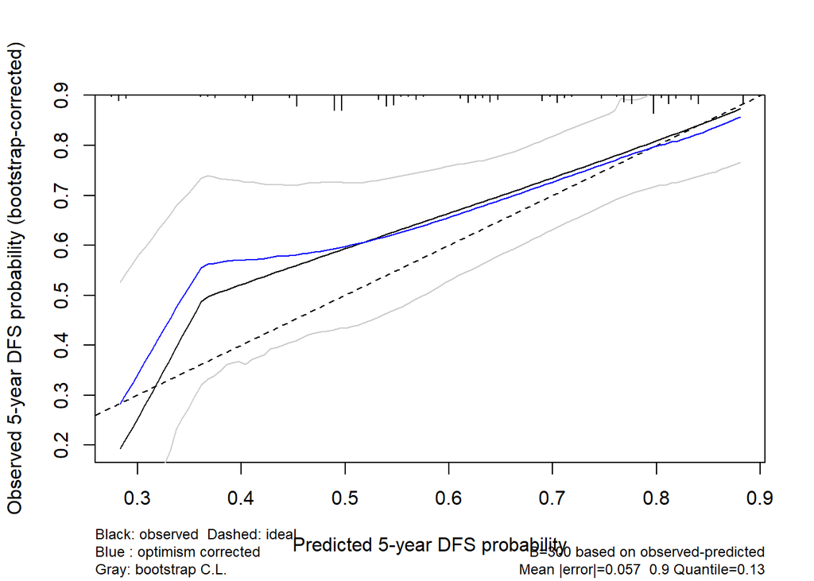

Bootstrap-corrected calibration at 5 years (predicted vs. observed DFS probability), complete-case sensitivity check.

```r
plot(cal, xlab = "Predicted 5-year DFS probability",
     ylab = "Observed 5-year DFS probability (bootstrap-corrected)")
```

*Note:* two different calibration metrics appear in this document. The calibration **slope** reported earlier (Section “Multiple imputation-pooled bootstrap optimism-correction”) is pooled across the 20 imputed datasets, consistent with multiple imputation as the primary analysis strategy. The calibration **plot** shown above, by contrast, belongs to this complete-case sensitivity check.

#### Time-dependent AUC, Brier score and Index of Prediction Accuracy (complete-case)

This is the complete-case sensitivity-check counterpart to the multiple imputation-pooled version reported in Section “Multiple imputation-pooled bootstrap optimism-correction”. As a modern complement to the C-index/calibration-slope summary above, we use `riskRegression::Score()` with bootstrap cross-validation to obtain time-dependent AUC(t), the Brier score, and the Index of Prediction Accuracy (IPA) at 1, 3 and 5 years.

```r
fit_std <- coxph(Surv(days, rezs) ~ PMP22_f + pT + pN_f + G + ER_f,
                  data = cc, x = TRUE, y = TRUE)

set.seed(202625)
sc <- Score(list("Full model" = fit_std),
            formula = Surv(days, rezs) ~ 1,
            data = cc,
            times = c(365, 3 * 365, 5 * 365),
            metrics = c("auc", "brier"),
            summary = "ipa",
            split.method = "bootcv", B = 100, M = 150,
            progress.bar = NULL)
sc
```

```
Metric AUC:

Results by model:

        model times    AUC  lower  upper
       <fctr> <num> <char> <char> <char>
1: Full model   365   77.4   42.5   98.4
2: Full model  1095   71.3   55.1   85.5
3: Full model  1825   70.6   58.4   84.2

Results of model comparisons:

Empty data.table (0 rows and 6 cols): model,times,reference,delta.AUC,lower,upper
```

```
Metric Brier:

Results by model:

        model times  Brier  lower  upper        IPA
       <fctr> <num> <char> <char> <char>      <num>
1: Null model   365    4.8    1.2    9.4 0.00000000
2: Null model  1095   18.6   14.4   23.3 0.00000000
3: Null model  1825   23.7   20.6   27.8 0.00000000
4: Full model   365    4.6    1.1    9.1 0.03088370
5: Full model  1095   16.7   12.4   22.0 0.09977094
6: Full model  1825   21.0   16.6   26.1 0.11546987

Results of model comparisons:

        model times  reference delta.Brier  lower  upper
       <fctr> <num>     <fctr>      <char> <char> <char>
1: Full model   365 Null model        -0.1   -0.4    0.2
2: Full model  1095 Null model        -1.9   -3.8    0.5
3: Full model  1825 Null model        -2.7   -5.7    1.6
```

```
Bootstrap cross-validation based on 100 bootstrap subsamples (drawn without replacement) each of size 150.
```

**Interpreting the output:** - AUC(t) is Uno’s time-dependent area under the ROC curve: for patients still at risk at time $t$, the probability that a patient who has the event by $t$ was assigned a higher predicted risk than a patient who is event-free through $t$. It ranges from 0.5 (no discrimination, equivalent to chance) to 1 (perfect discrimination), on the same conceptual scale as Harrell’s C-index, but is evaluated separately at each fixed horizon (1, 3, 5 years here) rather than averaged over the whole follow-up. - The Brier score is the time-dependent mean squared error between observed event status and predicted event probability at $t$. It reflects both discrimination and calibration jointly and ranges from 0 (perfect prediction) up to about 0.25 for an uninformative model at a 50% event rate, with lower values indicating better overall accuracy. - The Index of Prediction Accuracy (IPA) rescales the Brier score relative to a reference model without covariates (the marginal Kaplan-Meier estimate). IPA = 1 is perfect prediction, IPA = 0 means the model is no better than the covariate-free reference, and negative values mean the model performs *worse* than that reference. The `Full model` estimates reported by `Score()` above are already bootstrap-cross-validation corrected for optimism (`split.method = "bootcv"`), analogous to the optimism-correction applied to the C-index and calibration slope earlier.

## A.10 : Conditional predicted survival curves

As hazard ratios are abstract, a profile-based illustration (predicted disease-free survival (DFS) curves for a representative covariate pattern, contrasting PMP22-high vs. PMP22-low with the other covariates held at their reference (median/modal) values) makes the model concrete. It mirrors Figure 1C/1D of the original publication.

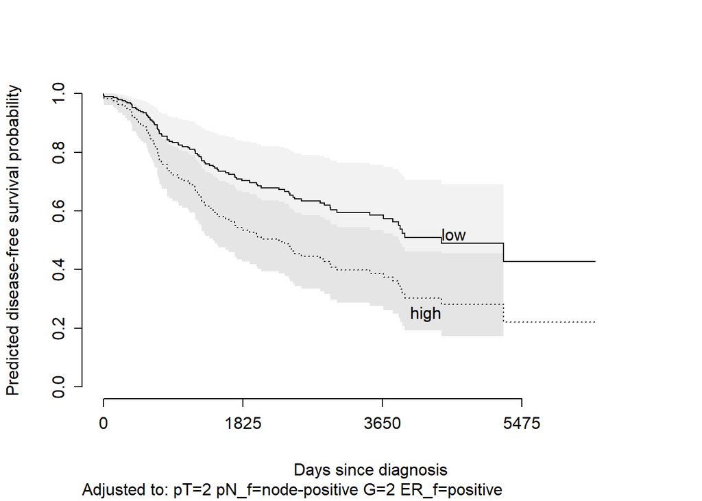

Model-based disease free survival predictions for PMP22-low vs. PMP22-high patients, other covariates fixed at reference (median/modal) values.

```r
survplot(fit_cph, PMP22_f = c("low", "high"),
         conf.int = 0.95, conf = "bands",
         xlab = "Days since diagnosis",
         ylab = "Predicted disease-free survival probability",
         label.curves = TRUE)
```

## A.11 Reporting

To highlight how this pre-specified analysis plan would read once written up for a clinical journal, this subsection presents a concise, self-contained results write-up.

**Illustrative results write-up, as in a published paper**

> **Methods (brief).** In a retrospective multicentre cohort of women with primary breast cancer (Tong et al. 2010), PMP22 gene expression and four established clinical factors (tumour size (pT), nodal status (pN), tumour grade (G) and estrogen receptor status (ER)) were evaluated as predictors of disease-free survival (DFS). All five predictors were specified a priori on clinical grounds; none was added or dropped based on its own association with outcome. The primary analysis fitted a multivariable Cox proportional-hazards model with all five predictors entered simultaneously, with missing predictor values handled by multiple imputation (20 imputed datasets, multivariate imputation by chained equations) and estimates combined with Rubin’s rules. Because the proportional- hazards assumption was violated for ER (scaled Schoenfeld residuals), a pre-specified ER x log(follow-up time) interaction term was included to let the ER effect vary over follow-up. A complete-case analysis served as a sensitivity check. Model performance was assessed for the corresponding model without the ER x log(follow-up time) term (constant ER effect) and summarised by Harrell’s C-index, a bootstrap-based calibration slope, Nagelkerke’s explained-variation measure (pseudo-R<sup>2</sup>), and time-dependent AUC, Brier score and Index of Prediction Accuracy (IPA) at 1, 3 and 5 years, each corrected for optimism by bootstrap resampling repeated within every imputed dataset.

#### Patients

Of 249 patients in the original cohort, 248 were available in the public analysis dataset. Of these, 208 (84%) had complete data on all five predictors and were additionally used for complete-case sensitivity analyses; the remaining 40 patients (16%) had at least one missing predictor and were included, via multiple imputation, in the primary analysis population of all 248 patients (Figure 1). Over a median potential follow-up of 8.9 years (reverse Kaplan-Meier estimate), 109 (44%) of 248 patients experienced disease recurrence or death.

```r
grViz('
digraph report_flow {
  graph [layout = dot, rankdir = TB, nodesep = 0.4, ranksep = 0.45,
         fontsize = 11, fontname = Helvetica]
  node [shape = box, style = "rounded,filled", fillcolor = "#F2F2F2",
        color = "#4D4D4D", fontname = Helvetica, fontsize = 11,
        margin = "0.25,0.15"]
  edge [fontname = Helvetica, fontsize = 9, color = "#4D4D4D"]

  orig [label = "249 patients enrolled\\n(original cohort)"]
  pub  [label = "248 patients in the\\npublic analysis dataset"]
  cc   [label = "208 complete cases"]

  orig -> pub [label = "1 patient not available\\nin public dataset"]
  pub  -> cc [label = "40 patients with\\n>=1 missing predictor"]
}
')
```

[interactive chart not shown]

Figure 1. Patient flow.

#### Baseline characteristics

Table 1 summarises the baseline distribution of all five predictors among all 248 patients in the primary analysis population with missing values shown as their own category.

```r
report_row <- function(varname, label, data = df) {
  x <- data[[varname]]
  cats   <- c(levels(x), "Missing")
  counts <- c(table(x, useNA = "no"), sum(is.na(x)))
  data.frame(Variable = c(label, rep("", length(cats) - 1)),
             Category = cats,
             `N (%)`  = sprintf("%d (%.1f%%)", counts, 100 * counts / nrow(data)),
             check.names = FALSE)
}

report_tab1 <- rbind(
  report_row("PMP22_f", "PMP22 expression"),
  report_row("pN_f",    "Nodal status"),
  report_row("ER_f",    "Estrogen receptor status"),
  report_row("pT_f",    "Tumour stage"),
  report_row("G_f",     "Tumour grade")
)
kable(report_tab1, row.names = FALSE)
```

Table 1. Baseline characteristics of all analysed patients.

| Variable | Category | N (%) |
| --- | --- | --- |
| PMP22 expression | low | 123 (49.6%) |
|  | high | 124 (50.0%) |
|  | Missing | 1 (0.4%) |
| Nodal status | node-negative | 96 (38.7%) |
|  | node-positive | 123 (49.6%) |
|  | Missing | 29 (11.7%) |
| Estrogen receptor status | negative | 116 (46.8%) |
|  | positive | 131 (52.8%) |
|  | Missing | 1 (0.4%) |
| Tumour stage | pT1 | 66 (26.6%) |
|  | pT2 | 127 (51.2%) |
|  | pT3/pT4 | 37 (14.9%) |
|  | Missing | 18 (7.3%) |
| Tumour grade | G1 | 33 (13.3%) |
|  | G2 | 122 (49.2%) |
|  | G3 | 72 (29.0%) |
|  | Missing | 21 (8.5%) |

#### Results

The primary analysis was based on all 248 patients, with missing predictor values handled by multiple imputation. All five prespecified variables were retained in the multivariable model.

Because the proportional-hazards assumption was violated for ER status, the ER effect was modelled as time-varying using an ER × log(follow-up time) interaction. The effect of PMP22, tumour stage, nodal status and tumour grade was modelled as proportional over follow-up.

```r
i_pmp22 <- match("PMP22 (high vs. low)", hr_table$term)

pmp22_report <- data.frame(
  `PMP22 expression` = "High vs. low",
  `Adjusted HR (95% CI)` =
    sprintf("%.2f (%.2f–%.2f)",
            hr_table$HR[i_pmp22],
            hr_table$CI_low[i_pmp22],
            hr_table$CI_high[i_pmp22]),
  `P value` =
    format.pval(hr_table$p_value[i_pmp22],
                digits = 3, eps = 0.001),
  check.names = FALSE
)

knitr::kable(
  pmp22_report,
  row.names = FALSE,
  align = c("l", "r", "r")
)
```

Table 2. Adjusted association between PMP22 expression and disease-free survival.

| PMP22 expression | Adjusted HR (95% CI) | P value |
| --- | --- | --- |
| High vs. low | 1.47 (0.94–2.29) | 0.09 |

After adjustment for tumour stage, nodal status, tumour grade and the time-varying effect of ER status, patients with high PMP22 expression had an estimated 47% higher hazard of disease recurrence or death than patients with low PMP22 expression (adjusted hazard ratio [HR] 1.47, 95% confidence interval [CI] 0.94–2.29; p = 0.090; Table 2). The confidence interval is compatible with effects ranging from a 6% lower hazard to more than twice the hazard, indicating substantial uncertainty around the magnitude of the association.

Figure 3 translates the estimated PMP22 effect into predicted disease-free survival for patients with otherwise identical reference covariate values. Predicted disease-free survival was lower for PMP22-high than for PMP22-low patients, consistent with the adjusted HR above 1. The curves represent a single covariate pattern and should not be interpreted as population-averaged survival estimates.

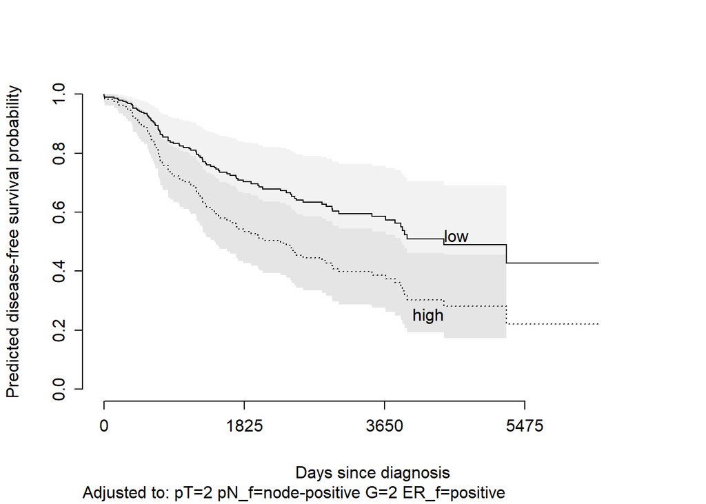

Figure 3. Model-based disease-free survival according to PMP22 expression, with other covariates fixed at reference values.

```r
survplot(
  fit_cph,
  PMP22_f = c("low", "high"),
  conf.int = 0.95,
  conf = "bands",
  xlab = "Days since diagnosis",
  ylab = "Predicted disease-free survival probability",
  label.curves = TRUE
)
```

*Model performance*

Because the time-varying ER effect does not yield a single fixed prognostic score over follow-up, the performance measures reported below refer to the corresponding model with a constant ER effect. They should therefore be interpreted as performance measures for this simplified prediction model, not as direct validation of the primary time-varying-effect model.

```r
se_fmt <- function(x)
  ifelse(is.na(x), "–", sprintf("%.3f", x))

# Overall performance measures
perf_overall <- data.frame(
  Metric = c(
    "C-index",
    "Calibration slope"
  ),
  Horizon = "Overall",
  Estimate = sprintf(
    "%.3f",
    c(pooled_C, pooled_slope)
  ),
  SE = se_fmt(
    c(pooled_se, pooled_slope_se)
  )
)

# Time-dependent AUC
perf_auc <- data.frame(
  Metric = "Time-dependent AUC",
  Horizon = horizon,
  Estimate = sprintf(
    "%.3f",
    pooled_auc$estimate
  ),
  SE = se_fmt(
    pooled_auc$se
  )
)

# Combine and display
knitr::kable(
  rbind(perf_overall, perf_auc),
  row.names = FALSE,
  align = c("l", "l", "r", "r")
)
```

Table 3. Optimism-corrected performance of the Cox model with a constant ER effect.

| Metric | Horizon | Estimate | SE |
| --- | --- | --- | --- |
| C-index | Overall | 0.670 | 0.014 |
| Calibration slope | Overall | 0.880 | 0.153 |
| Time-dependent AUC | 1 year | 0.659 | 0.109 |
| Time-dependent AUC | 3 years | 0.703 | 0.054 |
| Time-dependent AUC | 5 years | 0.673 | 0.051 |

The optimism-corrected C-index was 0.67 (SE 0.014), indicating moderate discrimination. The calibration slope was 0.88 (SE 0.153). Time-dependent AUCs were 0.66 at 1 year, 0.70 at 3 years and 0.67 at 5 years.

### Conclusion

In this cohort, higher PMP22 expression was associated with a higher hazard of disease recurrence or death after adjustment for prespecified clinical factors. The estimated effect was clinically meaningful in magnitude (HR 1.47), but the confidence interval was wide and included the null, indicating that the available data do not precisely determine the size of the association.

# 2 SAP B: Univariable pre-screening. A common but flawed practice

## Overview

The workflow below is deliberately built to reproduce mistakes that are routinely seen in applied practice. It screens each candidate predictor’s univariable ( marginal) association with the outcome, keeps only variables that pass a significance filter, and treats the resulting reduced model as if it had been pre-specified.

## B.1 Univariable screening

Each predictor is tested **on its own**, using whatever cases happen to be non-missing for that single variable. Therefore, the sample size silently differs from test to test, a detail that is rarely reported in practice.

```r
vars <- c("PMP22", "pT", "pN", "G", "ER")
uni_results <- do.call(rbind, lapply(vars, function(v) {
  d <- df[!is.na(df[[v]]), ]
  form <- as.formula(paste0("Surv(days, rezs) ~ ", v))
  fit <- coxph(form, data = d)
  s <- summary(fit)
  data.frame(variable = v, n = nrow(d),
             HR = round(s$coefficients[, "exp(coef)"], 2),
             p_value = s$coefficients[, "Pr(>|z|)"])  # full precision; used for the screen below
}))

uni_display <- uni_results
uni_display$p_value <- format.pval(uni_display$p_value, digits = 3, eps = 0.001)
kable(uni_display, row.names = FALSE,
      caption = "Step 1: univariable Cox regressions, each on its own available cases.")
```

Step 1: univariable Cox regressions, each on its own available cases.

| variable | n | HR | p_value |
| --- | --- | --- | --- |
| PMP22 | 247 | 1.01 | 0.978 |
| pT | 230 | 1.32 | 0.061 |
| pN | 219 | 2.72 | <0.001 |
| G | 227 | 1.06 | 0.702 |
| ER | 247 | 0.63 | 0.017 |

## B.2 Apply a significance filter

Here we will use 0.05 as significance criterion.

```r
alpha_screen <- 0.05
selected <- uni_results$variable[uni_results$p_value < alpha_screen]
dropped  <- setdiff(vars, selected)
cat("Retained after univariable screen (p <", alpha_screen, "):",
    paste(selected, collapse = ", "), "\n")
```

```
Retained after univariable screen (p < 0.05 ): pN, ER
```

```r
cat("Dropped (including, notably, PMP22 — the variable of primary interest):",
    paste(dropped, collapse = ", "), "\n")
```

```
Dropped (including, notably, PMP22 — the variable of primary interest): PMP22, pT, G
```

PMP22 (p = 0.978) and `G` are dropped outright, and `pT` (p = 0.061) narrowly misses the threshold too. The screen never gives PMP22 a chance to be assessed jointly with the clinical factors; exactly the assessment the study was designed to make. This happens because PMP22’s univariable association with disease-free survival is masked by its correlation with ER. Only *conditional* on ER (and the other factors) does PMP22’s prognostic value emerge.

## B.3 Multivariable model on the surviving subset

```r
cc_b <- df[complete.cases(df[, selected]), ]
cat("Complete-case n for the reduced model:", nrow(cc_b), "\n")
```

```
Complete-case n for the reduced model: 218
```

```r
form_b <- as.formula(paste("Surv(days, rezs) ~", paste(selected, collapse = " + ")))
fit_b_full <- coxph(form_b, data = cc_b)
summary(fit_b_full)
```

```
Call:
coxph(formula = form_b, data = cc_b)

  n= 218, number of events= 96

      coef exp(coef) se(coef)      z Pr(>|z|)
pN  1.0154    2.7606   0.2304  4.408 1.05e-05 ***
ER -0.4714    0.6241   0.2057 -2.292   0.0219 *
---
Signif. codes:  0 '***' 0.001 '**' 0.01 '*' 0.05 '.' 0.1 ' ' 1

   exp(coef) exp(-coef) lower .95 upper .95
pN    2.7606     0.3622     1.757    4.3361
ER    0.6241     1.6022     0.417    0.9341

Concordance= 0.682  (se = 0.026 )
Likelihood ratio test= 26.29  on 2 df,   p=2e-06
Wald test            = 23.92  on 2 df,   p=6e-06
Score (logrank) test = 25.55  on 2 df,   p=3e-06
```

A further backward-elimination step (here by AIC) is commonly layered on top “to simplify the model further”:

```r
fit_b_step <- stepAIC(fit_b_full, direction = "backward", trace = 1)
```

```
Start:  AIC=898.73
Surv(days, rezs) ~ pN + ER

       Df    AIC
<none>    898.73
- ER    1 902.00
- pN    1 918.62
```

```r
summary(fit_b_step)
```

```
Call:
coxph(formula = Surv(days, rezs) ~ pN + ER, data = cc_b)

  n= 218, number of events= 96

      coef exp(coef) se(coef)      z Pr(>|z|)
pN  1.0154    2.7606   0.2304  4.408 1.05e-05 ***
ER -0.4714    0.6241   0.2057 -2.292   0.0219 *
---
Signif. codes:  0 '***' 0.001 '**' 0.01 '*' 0.05 '.' 0.1 ' ' 1

   exp(coef) exp(-coef) lower .95 upper .95
pN    2.7606     0.3622     1.757    4.3361
ER    0.6241     1.6022     0.417    0.9341

Concordance= 0.682  (se = 0.026 )
Likelihood ratio test= 26.29  on 2 df,   p=2e-06
Wald test            = 23.92  on 2 df,   p=6e-06
Score (logrank) test = 25.55  on 2 df,   p=3e-06
```

## B.4 Missing data

No missing-data mechanism is examined. Each stage above uses whichever complete cases happen to be available for the variables involved at that stage (247/248 at the univariable stage for `PMP22` and `ER`, 230 for `pT`, 219 for `pN`, 227 for `G`; 218 for the final reduced model). These inconsistent sample sizes that are easy to lose track of and rarely reconciled in reports built this way.

## B.5 Interactions and assumptions — not checked

In a workflow like this, interaction terms and modeling assumptions (proportional hazards, functional form, influential points) are typically **not** examined once a “final” reduced model has been reached. We deliberately do not run them here either, to reflect this common practice. Part A shows what they would have revealed. (Notably, the `ER` proportional-hazards violation, which affects conclusions about `PMP22` specifically.)

## B.6 Reporting

The coefficients, hazard ratios, confidence intervals and p-values from `fit_b_step` would typically be reported as if `pN` and `ER` had been the pre-specified variables of interest, with language such as “independent prognostic factors,” and with no acknowledgment that they were chosen because of, not despite, their own association with the outcome. The resulting standard errors and p-values do not account for the selection process and are anti-conservative.

## B.7 Apparent-only performance

```r
concordance(fit_b_step)
```

```
Call:
concordance.coxph(object = fit_b_step)

n= 218
Concordance= 0.682 se= 0.02636
concordant discordant     tied.x     tied.y    tied.xy
      7222       2515       3197          2          2
```

This apparent (in-sample, non-validated) concordance is reported directly, with no bootstrap or cross-validation correction for optimism.

# 3 Summarized consequences

```r
comparison <- data.frame(
  Aspect = c("PMP22 in final model?", "Basis for inclusion", "Missing data handling",
             "Interactions checked?", "PH assumption checked?",
             "Inference validity", "Performance reported"),
  `Plan A (recommended)` = c(
    "Yes -- HR ~1.5-1.8, adjusted (complete-case p<0.05; multiple imputation-pooled primary p~0.09)",
    "Pre-specified a priori (clinical knowledge)",
    "Multiple imputation (+ complete case analysis sensitivity)",
    "Yes, pre-specified set, joint test",
    "Yes, ER violation found and corrected",
    "Valid (no selection on outcome)",
    "Bootstrap optimism-corrected"),
  `Plan B` = c(
    "No, eliminated at univariable screen",
    "Univariable p-value < 0.05",
    "Ad hoc complete case, inconsistent n",
    "Not considered",
    "Not checked",
    "Invalid (ignores selection uncertainty)",
    "Apparent (in-sample) only"),
  check.names = FALSE
)
kable(comparison)
```

| Aspect | Plan A (recommended) | Plan B |
| --- | --- | --- |
| PMP22 in final model? | Yes – HR ~1.5-1.8, adjusted (complete-case p<0.05; multiple imputation-pooled primary p~0.09) | No, eliminated at univariable screen |
| Basis for inclusion | Pre-specified a priori (clinical knowledge) | Univariable p-value < 0.05 |
| Missing data handling | Multiple imputation (+ complete case analysis sensitivity) | Ad hoc complete case, inconsistent n |
| Interactions checked? | Yes, pre-specified set, joint test | Not considered |
| PH assumption checked? | Yes, ER violation found and corrected | Not checked |
| Inference validity | Valid (no selection on outcome) | Invalid (ignores selection uncertainty) |
| Performance reported | Bootstrap optimism-corrected | Apparent (in-sample) only |

The two workflows applied to the **same 248 patients** reach opposite conclusions about the variable the study was designed to evaluate. Plan B is not a hypothetical strawman: the univariable p-values obtained here (`PMP22` p $\approx$ 0.98, `pT` p $\approx$ 0.06, `G` p $\approx$ 0.70) closely match those reported in the original publication’s own univariable analysis. The authors explicitly *did not* use them for pre-screening, and it is precisely because they used a pre-specified multivariable model instead that PMP22’s prognostic value was discovered at all.

# 4 Computing Environment

**Use of AI:** The code implementing the two statistical analysis plans was generated with AI assistance (Claude, Anthropic). The authors critically reviewed, revised, and adapted AI-generated content and code.

## References

Heinze, Georg, and Dan Tong. 2026. “Gene Expression of PMP22 and Recurrence-Free Survival After Breast Cancer.” Zenodo. https://doi.org/10.5281/zenodo.19632792.

Tong, Dan, Georg Heinze, Dietmar Pils, Andrea Wolf, Christian F Singer, Nicole Concin, Gerda Hofstetter, Ingrid Schiebel, Margaretha Rudas, and Robert Zeillinger. 2010. “Gene Expression of PMP22 Is an Independent Prognostic Factor for Disease-Free and Overall Survival in Breast Cancer Patients.” *BMC Cancer* 10 (1): 682. https://doi.org/10.1186/1471-2407-10-682.

White, Ian R., and Patrick Royston. 2009. “Imputing Missing Covariate Values for the Cox Model.” *Statistics in Medicine* 28 (15): 1982–98. https://doi.org/10.1002/sim.3618.